# 1 Introduction

## What is FND

Functional neurological disorder (FND) is a condition where there are changes in the functioning of the nervous system (the brain and the spinal cord). This is different to a neurological condition where there is structural damage or changes in the brain or spinal cord. There is no structural damage in functional neurological disorder (FND), but this does not mean that the symptoms are not real. They just have a different cause. Functional neurological disorder (FND) symptoms – or ‘functional neurological symptoms’ - are caused by a disruption in the communication between the nerves of the brain and the body. This disruption is caused by physical and emotional stress that a person is experiencing.

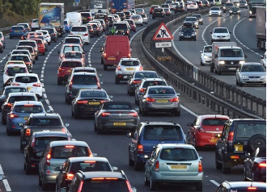

One way to think of FND is like a motorway. If the nervous system is functioning normally, the motorway traffic is flowing freely, where everyone is going at a similar speed and not stopping.

In FND, it is like there are lots of traffic jams, so the traffic flows for a short while, then it all grinds to a halt, then starts again, then stops, and so on. This will cause intermittent, or irregular, signals from the brain to the body, and therefore causes functional neurological symptoms.

## Types of FND

There are different types of FND symptoms. You may have one or more than one of these:

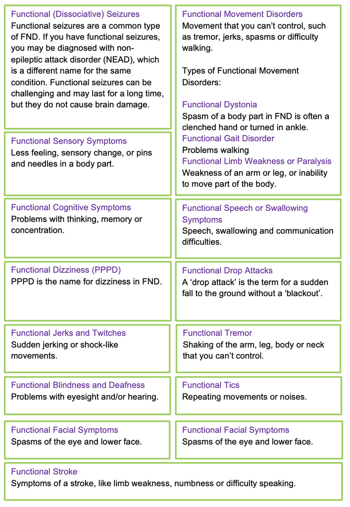

## Diagnosing FND

You may have had tests from different healthcare professionals, including a Neurologist. They follow an in-depth and scientific process to get a clear picture of what you’re experiencing.

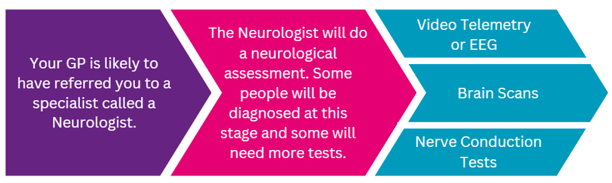

[figure not shown]

The results for these tests come back normal in FND. In neurological conditions they are abnormal.

## FND is REAL

Feeling like people don’t believe you or fighting to get the right diagnosis can actually make your symptoms worse. But, FND symptoms are real and can be treated. Healthcare professionals will have a clearer picture of why you have these symptoms after these tests. They will be able to guide you in the next steps.

## Knowledge Check

**Questions**

1. FND is caused by *functional* rather than *structural* problems in the brain (TRUE or FALSE)?
2. Functional seizures are a common type of FND (TRUE or FALSE)?
3. There are no tests that can diagnose FND (TRUE or FALSE)

**Answers**

1. FND is caused by *functional* rather than *structural* problems in the brain. TRUE or FALSE?

   `TRUE`, this is what makes FND different to a neurological condition. There is no damage to the structure of the brain in FND.
2. Functional seizures are a common type of FND. TRUE or FALSE?

   `TRUE`, there are many different types of FND, and functional seizures is one of the most common. Functional seizures are different to epilepsy because there is no damage to the brain causing the seizure.
3. There are no tests that can diagnose FND. TRUE or FALSE?

   `FALSE`, there are different in-depth and scientific tests that can help diagnose FND. For example: brain scans, video telemetry and nerve conduction tests.